# Prediction Assignment

Zulkhairi MD

January 29, 2016

## Executive Summary

This project is an assignment to predict how well participants in an exercise program do their exercises. Data from accelerometers on the belt, forearm, arm, and dumbell of 6 participants was used and split into training data and testing data. More information can be found from the website http://groupware.les.inf.puc-rio.br/har. The author would like to acknowledge the work by Velloso et al. (2013) for providing the WLE data set.

## Exploratory Data Analysis

### Preprocessing

Both the training and testing data sets were downloaded from https://d396qusza40orc.cloudfront.net/predmachlearn/pml-training.csv and https://d396qusza40orc.cloudfront.net/predmachlearn/pml-testing.csv

```r
#download.file("http://d396qusza40orc.cloudfront.net/predmachlearn/pml-training.csv", #"./pml-training.csv")
#download.file("http://d396qusza40orc.cloudfront.net/predmachlearn/pml-training.csv", #"./pml-testing.csv")
traindat <- read.csv("pml-training.csv")
#colnames(traindat)#contains 160 variables with classe as the outcome variable
#summary(traindat)#there are 19622 rows
testdat <- read.csv("pml-testing.csv")
#colnames(testdat)#contains 160 variables
#summary(testdat)#there are 20 rows
```

### Data Cleansing

Variables in first 7 columns such as index, name, timestamps and windows are discarded since they are not used for prediction. Same with variables with more than 95% NAs are removed.

```r
discardCols <- grep("name|timestamp|window|X", colnames(traindat), value=F)
traindat <- traindat[-discardCols]#remove the first 7 columns from the data set
testdat <- testdat[-discardCols]
#There are many variables with more than 95% NAs, and these are also discarded from the data set.
traindat[traindat==""] <- NA#some variables with blanks are assigned as NAs and are also removed.
testdat[testdat==""] <- NA
traindat <- traindat[, colSums(is.na(traindat)) < nrow(traindat)*0.95]#keep variables with at least 95% non-NAs. This results in 53 usable variables including the outcome variable.
testdat <- testdat[, colSums(is.na(testdat)) < nrow(testdat)*0.95]
```

The cleaned data sets traindat and testdat have 53 variables with both having the same first 52 variables followed by the last variable classe in the traindat and problem_id in testdat. traindat has 19622 rows whilst testdat has 20 rows.

## Split training data set

traindat is split into training set (70%) for prediction and validation set (30%) to find the out of-sample-error.

```r
library(caret)
set.seed(1234)
inTrain <- createDataPartition(traindat$classe, p = 0.7, list = FALSE)
training <- traindat[inTrain, ]
validation <- traindat[-inTrain, ]
```

Training set has 13737 rows and validation set has 5885 rows.  
The training and validation sets is based on the participants’ exercises grouped into 5 different classes. With the exception of class A, which corresponds to the right way of doing the exercise, the other 4 classes correspond to common mistakes made during the exercise. The distribution of the classes is shown in the following graph based on the training and validation sets.

```r
library(dplyr)
```

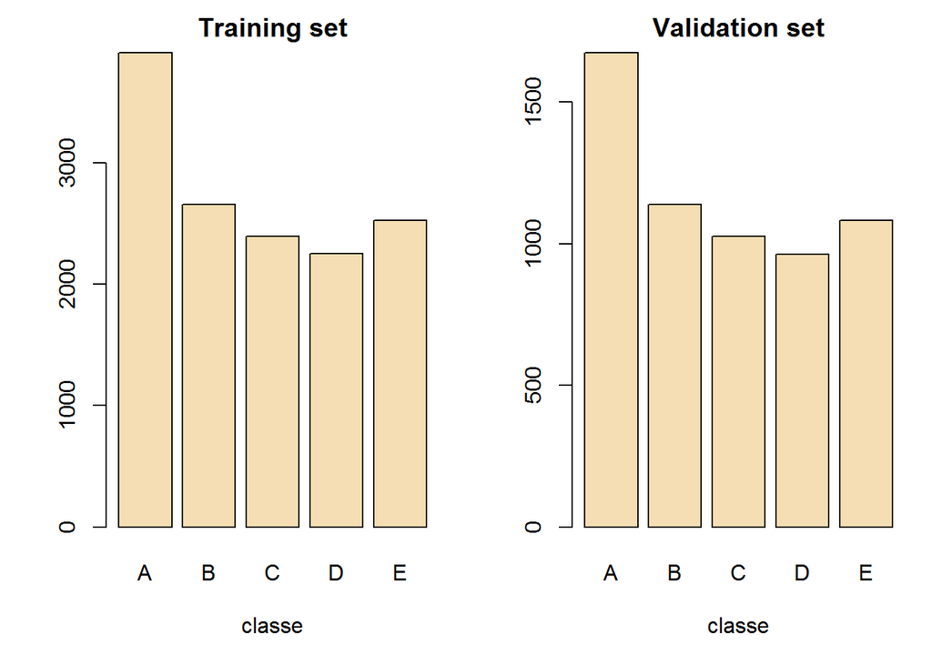

```r
par(mfrow = c(1, 2), mar = c(5, 4, 2, 1))
table(training$classe) %>% barplot(col = "wheat", xlab = "classe", main = "Training set")
table(validation$classe) %>% barplot(col = "wheat", xlab = "classe", main = "Validation set")
```

Based on the graphs, both training and validation sets are equally distributed. This should give an accurate cross validation and prediction of the outcome.  
K-fold cross validation is used on the training set to predict the outcome.

```r
library(rpart); library(rpart.plot); library(rattle); library(caret)
#Prepare for parallel processing to be used later in time-consuming random forest algorithm.
#Configure parallel processing
library(parallel); require(iterators);require(foreach)
library(doParallel)
cluster <- makeCluster(detectCores() - 1)#leave 1 core for OS
registerDoParallel(cluster)
#Configure trainControl object.
fitControl <- trainControl(method = "cv", #cross-validation
                           number = 10, #using k-fold cross-validation
                           allowParallel = TRUE)#enable parallel processing
#Develop training model
#Train the model using trainControl() object created.
#fit <- train(classe ~. , method = "rf", data = training, trControl = fitControl)#less than 10 secs.
#De-register parallel processing cluster
#stopCluster(cluster)#shut down the cluster for parallel processing

#control <- trainControl(method = "cv", number = 5)#cross-validation
fitRpart <- train(classe ~., data = training, method = "rpart", trControl = fitControl)#if connection failed, need to re-run R due to previous parallel processing
print(fitRpart)
```

```
## CART
##
## 13737 samples
##    52 predictor
##     5 classes: 'A', 'B', 'C', 'D', 'E'
##
## No pre-processing
## Resampling: Cross-Validated (10 fold)
## Summary of sample sizes: 12364, 12364, 12364, 12363, 12363, 12362, ...
## Resampling results across tuning parameters:
##
##   cp          Accuracy   Kappa       Accuracy SD  Kappa SD
##   0.03549995  0.5387628  0.41366080  0.02221118   0.03824999
##   0.06092971  0.3795566  0.14706504  0.03967405   0.06683495
##   0.11738379  0.3327524  0.07387825  0.04179427   0.06365854
##
## Accuracy was used to select the optimal model using  the largest value.
## The final value used for the model was cp = 0.03549995.
```

[figure not shown]

```r
fancyRpartPlot(fitRpart$finalModel)
```

```r
#Use the train model to predict the accuracy of the validation set
predRpart <- predict(fitRpart, validation)
confusionMatrix(validation$classe, predRpart)#display results
```

```
## Confusion Matrix and Statistics
##
##           Reference
## Prediction    A    B    C    D    E
##          A 1530   35  105    0    4
##          B  486  379  274    0    0
##          C  493   31  502    0    0
##          D  452  164  348    0    0
##          E  168  145  302    0  467
##
## Overall Statistics
##
##                Accuracy : 0.489
##                  95% CI : (0.4762, 0.5019)
##     No Information Rate : 0.5317
##     P-Value [Acc > NIR] : 1
##
##                   Kappa : 0.3311
##  Mcnemar's Test P-Value : NA
##
## Statistics by Class:
##
##                      Class: A Class: B Class: C Class: D Class: E
## Sensitivity            0.4890   0.5027   0.3279       NA  0.99151
## Specificity            0.9478   0.8519   0.8797   0.8362  0.88641
## Pos Pred Value         0.9140   0.3327   0.4893       NA  0.43161
## Neg Pred Value         0.6203   0.9210   0.7882       NA  0.99917
## Prevalence             0.5317   0.1281   0.2602   0.0000  0.08003
## Detection Rate         0.2600   0.0644   0.0853   0.0000  0.07935
## Detection Prevalence   0.2845   0.1935   0.1743   0.1638  0.18386
## Balanced Accuracy      0.7184   0.6773   0.6038       NA  0.93896
```

Result of the classification tree shows accuracy less than 50%, hence model is not a good predictor of classe.

### Random Forest

Use the random forest cross validation to compare the accuracy and out-of-sample error and later use the train model to predict the accuracy of the validation set.

```r
library(randomForest)
fitRF <- train(classe ~., data = training, method = "rf", trControl = fitControl)#Without parallel 15 mins processing, with parallel 13.5 mins.
#De-register parallel processing cluster
stopCluster(cluster)#shut down the cluster for parallel processing
predRF <- predict(fitRF, validation)
confusionMatrix(validation$classe, predRF)#display results
```

```
## Confusion Matrix and Statistics
##
##           Reference
## Prediction    A    B    C    D    E
##          A 1674    0    0    0    0
##          B   10 1128    1    0    0
##          C    0    5 1017    4    0
##          D    0    2    5  955    2
##          E    0    1    2    3 1076
##
## Overall Statistics
##
##                Accuracy : 0.9941
##                  95% CI : (0.9917, 0.9959)
##     No Information Rate : 0.2862
##     P-Value [Acc > NIR] : < 2.2e-16
##
##                   Kappa : 0.9925
##  Mcnemar's Test P-Value : NA
##
## Statistics by Class:
##
##                      Class: A Class: B Class: C Class: D Class: E
## Sensitivity            0.9941   0.9930   0.9922   0.9927   0.9981
## Specificity            1.0000   0.9977   0.9981   0.9982   0.9988
## Pos Pred Value         1.0000   0.9903   0.9912   0.9907   0.9945
## Neg Pred Value         0.9976   0.9983   0.9984   0.9986   0.9996
## Prevalence             0.2862   0.1930   0.1742   0.1635   0.1832
## Detection Rate         0.2845   0.1917   0.1728   0.1623   0.1828
## Detection Prevalence   0.2845   0.1935   0.1743   0.1638   0.1839
## Balanced Accuracy      0.9970   0.9953   0.9952   0.9954   0.9984
```

Result shows 99% accuracy with very small out-of-sample error. Hence the model predicted using the random forest method is a good predictor of classe.

## Prediction of Test Data

Use the random forest method to predict the testdat data set.

```r
#fitRF$bestTune$mtry
RFmodel = randomForest(classe ~ ., data = training,
                            mtry = fitRF$bestTune$mtry)
predict(RFmodel, newdata = testdat)
```

```
##  1  2  3  4  5  6  7  8  9 10 11 12 13 14 15 16 17 18 19 20
##  B  A  B  A  A  E  D  B  A  A  B  C  B  A  E  E  A  B  B  B
## Levels: A B C D E
```

## Reference

Velloso, E., Bulling, A., Gellersen, H., Ugulino, W., & Fuks, H. Qualitative Activity Recognition of Weight Lifting Exercises. Proceedings of 4th International Conference in Cooperation with SIGCHI (Augmented Human ’13) . Stuttgart, Germany: ACM SIGCHI, 2013.

Read more: http://groupware.les.inf.puc-rio.br/har#ixzz3yn1IFZOD